# TECprogress

Fabian Blombach

18/10/2019

This script describes the generation of generalised linear models for the progression of TEC-Spt4/5 to TEC-Spt4/5-Elf1 during oxidative stress. Negative binomial models were used to model count data that showed overdispersion. Raw coverage of Elf1 in the promoter region was modelled. The normalisation against the chromatin input was built into the model by including an offest term with raw chromatin input coverage.

```r
knitr::opts_chunk$set(echo = TRUE)

data <- read.delim("EI_data.TSSvAUG.H2O2.txt", header=T)
TSS <- "TU_selection/TSS.uniqueTFBvTFEbOccup.TU500.intTFBfilt.H2O2.bed"
TSSbed <- read.table(TSS)
TSSbed$V4 <- as.character(TSSbed$V4)
nrows <- nrow (TSSbed)

#data available at https://www.ncbi.nlm.nih.gov/geo/query/acc.cgi?acc=GSE141286
#path to directory where data are stored
mydir<-("../NCBI_data/GSE141033_RAW/")

Inp1 <- paste0(mydir, "GSM4192714_input.H2O2_r1.Coverage.bw")
Inp2 <- paste0(mydir, "GSM4192715_input.H2O2_r2.Coverage.bw")
Spt45_r1 <- paste0(mydir, "GSM4192702_Spt45.H2O2_r1.Coverage.bw")
Spt45_r2 <- paste0(mydir, "GSM4192703_Spt45.H2O2_r2.Coverage.bw")
Elf1_r1 <- paste0(mydir, "GSM4192704_Elf1.H2O2_r1.Coverage.bw")
Elf1_r2 <- paste0(mydir, "GSM4192705_Elf1.H2O2_r2.Coverage.bw")


Sys.setenv(TSS = TSS, nrows = nrows, Inp1 = Inp1, Inp2 = Inp2, Spt45_r1 = Spt45_r1, Spt45_r2 = Spt45_r2, Elf1_r1 = Elf1_r1, Elf1_r2 = Elf1_r2)


require(ggplot2)
require(seqinr)
require(MASS)
require(car)
require(pscl)
```

```bash
export PATH=$PATH:/Users/fabianblombach/miniconda3/bin
if [ -d temp ]; then rm -Rf temp; fi
mkdir temp
bedtools slop -i $TSS -g  ../Genomes/Sso_NCBI/SsoP2.sizes -s -l 7 -r 4 > temp/slop.bed

bedtools getfasta -name -s -bed temp/slop.bed -fi ../Genomes/Sso_NCBI/NC_002754.fna -fo temp/DNA.fasta
```

```r
#Temperature in Kelvin
temp=349.15
#Salt concentration in molar
salt= 0.025

#load reference values from SantaLucia Jr paper (PNAS 1998)
NN<-read.table("~/HTS/scripts/NN_thermodynamics.txt", header=T, sep="\t")
NN$ΔH<-as.numeric(as.character(NN$ΔH))
NN$ΔS<-as.numeric(as.character(NN$ΔS))
#delH is in kcal/mol, while delS is in cal/mol*k, calculate the delG in kcal/mol
NN$ΔG <- NN$ΔH - (NN$ΔS*temp/1000)

#load alignment of promoter sequences (output from bedtools getfasta -tab)
require(seqinr)
input<-read.fasta("temp/DNA.fasta", forceDNAtolower=T)
mono<-as.data.frame(matrix(unlist(input), nrow=length(input), byrow=T), row.names=names(input))
row.names(mono)<-gsub('(+)',"",row.names(mono), fixed=T)
row.names(mono)<-gsub('(-)',"",row.names(mono), fixed=T)
# loop to make table with dinucleotides
dinuc<-matrix(rep("N", times=nrow(mono)*(ncol(mono)-1)), nrow=nrow(mono))
for (j in 1:nrow(mono)) {
  for (i in 1:(ncol(mono)-1)) {
  dinuc[j,i] <- paste0(mono[j,i], mono[j,i+1])
  }
}
# replace dinucleotides with corresponding deltaG values
dinucG<-dinuc
for (k in 1:16) {
dinucG[dinucG == NN[k,1]]<- NN[k,4]
}
dinucG<-data.frame(matrix(as.numeric(dinucG), ncol=ncol(dinuc)))


# replace monocleotides with corresponding deltaG values for terminal nucleotides
monoG<-as.matrix(mono, nrow=nrow(mono))
for (k in 17:20) {
  monoG[monoG == NN[k,1]]<- NN[k,4]
}
monoG<-data.frame(matrix(as.numeric(monoG), ncol=ncol(monoG)))
```

calculate Spt45Bd and input occupancy for linear modelling

```bash
export PATH=$PATH:/Users/fabianblombach/miniconda3/bin

#calculate input coverage
computeMatrix reference-point --sortRegions keep -bs 1 -a 100 -b 50 -R $TSS -S $Inp1 $Inp2 $Spt45_r1 $Spt45_r2 $Elf1_r1 $Elf1_r2 -o temp/trashme.npz --outFileNameMatrix temp/trashme.tab;
rm temp/trashme.npz;
head -n 2 temp/trashme.tab > temp/Coverage.tab;
tail -n $nrows temp/trashme.tab >> temp/Coverage.tab; rm temp/trashme.tab
```

read matrix file and split based on samples

```r
cov <- read.table(paste0("temp/Coverage.tab"), sep="\t", header=F)
Inp1_promCov <- rowMeans(cov[,1:150])
Inp2_promCov <- rowMeans(cov[,151:300])
Spt45_r1_promCov <- rowMeans(cov[,301:450])
Spt45_r2_promCov <- rowMeans(cov[,451:600])
Elf1_r1_promCov <- rowMeans(cov[,601:750])
Elf1_r2_promCov <- rowMeans(cov[,751:900])

covMeans<-data.frame(Inp1_promCov, Inp2_promCov, Spt45_r1_promCov, Spt45_r2_promCov, Elf1_r1_promCov, Elf1_r2_promCov)
```

Calculate deltaG for -5 ot +7 window by summing up dinucleotide G values

```r
width = 12
  deltaG <- rowSums(dinucG[,1:11]) - 0.114*(width-1)*log(salt)
dataMerged<-data.frame(deltaG, covMeans)
row.names(dataMerged)<-row.names(mono)
dataMerged<- merge(dataMerged, data, by.x="row.names", by.y="operon_id", sort=F)

summary(dataMerged$deltaG)
```

```
##    Min. 1st Qu.  Median    Mean 3rd Qu.    Max.
## -1.7992  0.3503  1.2731  1.1550  1.9791  3.7412
```

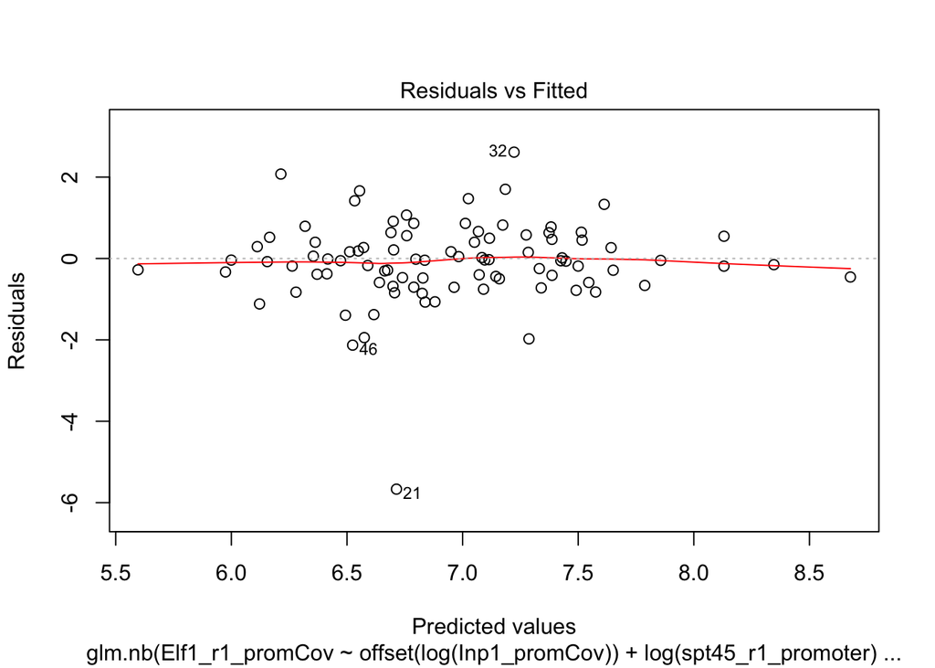

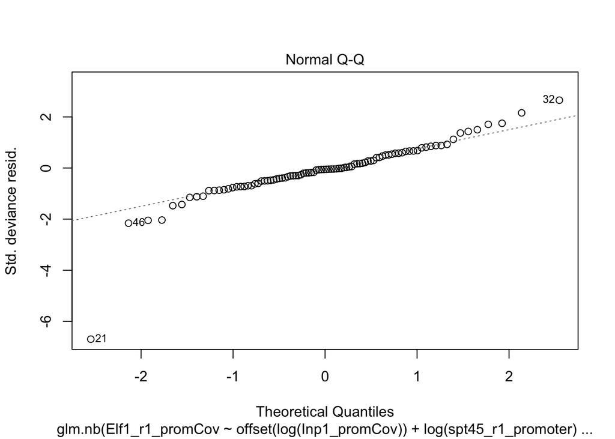

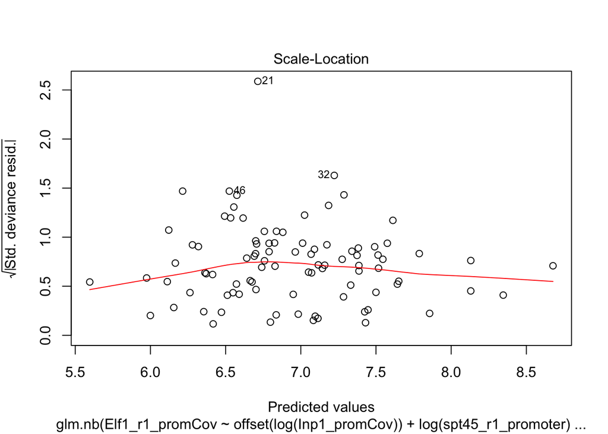

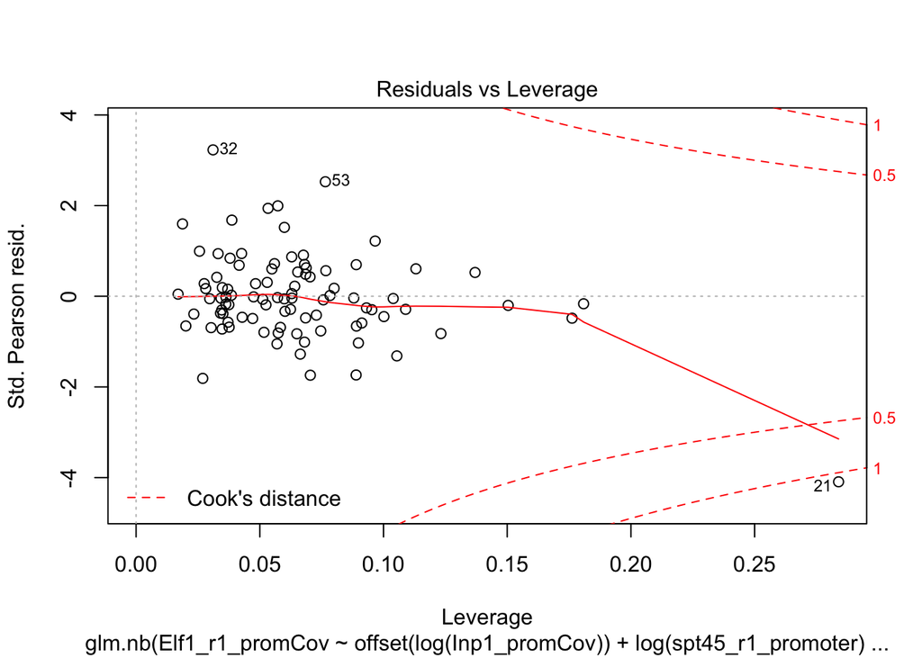

```r
#filtering out the rRNA operon from data frame
data.Merged2<-  subset(dataMerged, !(Row.names %in% c("ID_669")))
#a full model without interaction terms
model.full <- suppressWarnings(glm.nb(Elf1_r1_promCov ~ offset(log(Inp1_promCov)) + log(spt45_r1_promoter) + deltaG + log(TFB1_foldR1) + log(TFEb_foldR1) + log(cpsf1_r1_promoter), data=data.Merged2))
plot(model.full)
```

```r
#Row 21 in data frame is outlier. Removed from data frame!
dataMerged[row.names(data.Merged2) == 21,1]
```

[output not shown]

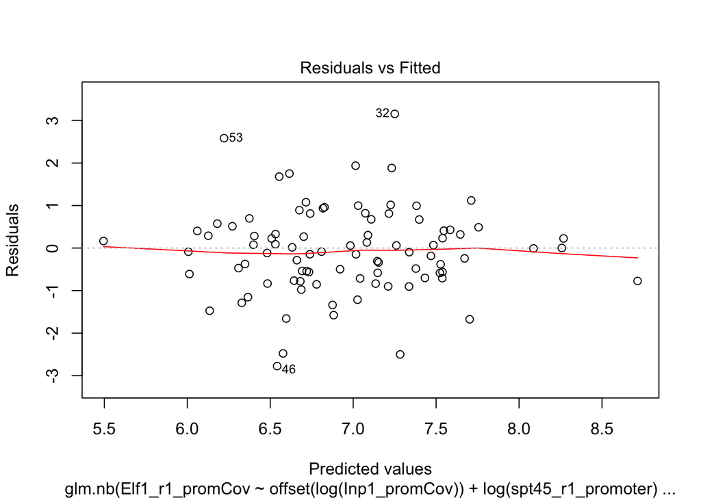

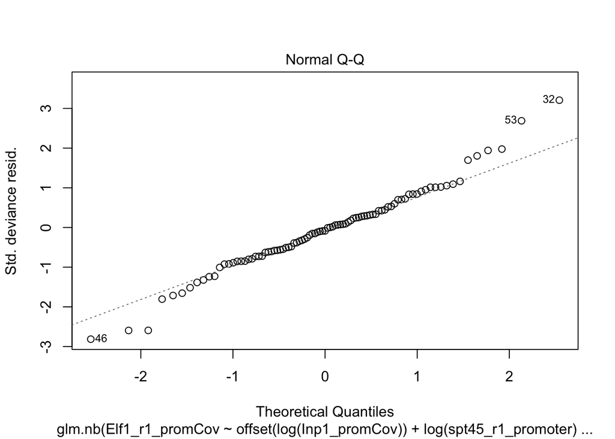

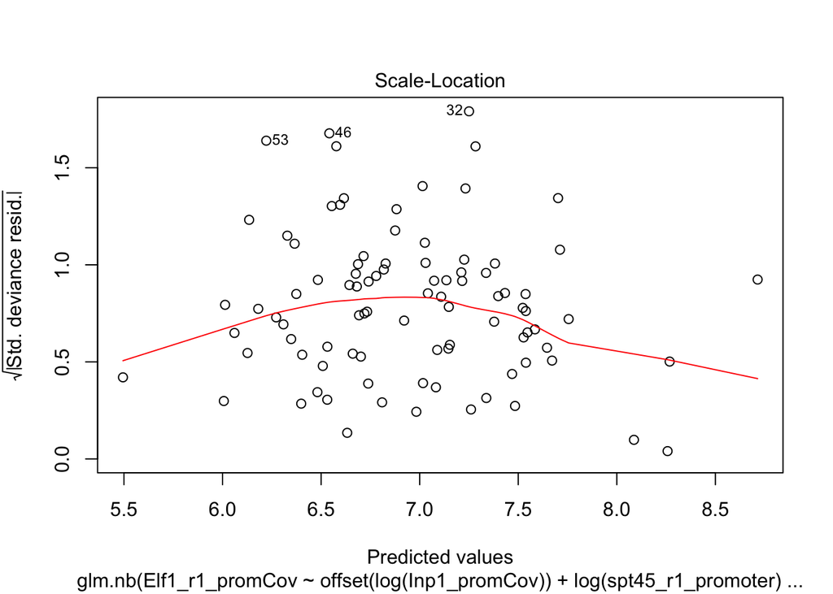

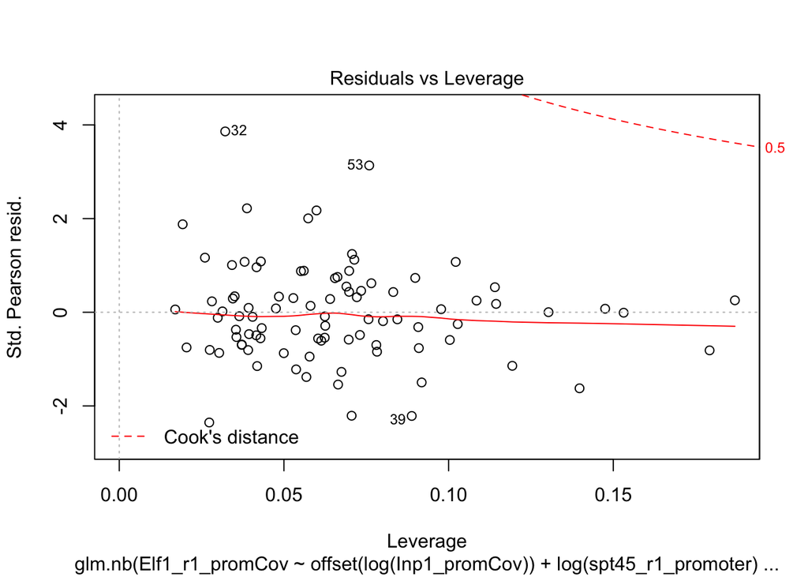

```r
data.mod<-  subset(dataMerged, !(Row.names %in% c("ID_2052", "ID_669")))
model.full <- suppressWarnings(glm.nb(Elf1_r1_promCov ~ offset(log(Inp1_promCov)) + log(spt45_r1_promoter) + deltaG + log(TFB1_foldR1) + log(TFEb_foldR1) + log(cpsf1_r1_promoter), data=data.mod))
plot(model.full)
```

```r
anova(model.full)
```

```
## Analysis of Deviance Table
##
## Model: Negative Binomial(29.098), link: log
##
## Response: Elf1_r1_promCov
##
## Terms added sequentially (first to last)
##
##
##                        Df Deviance Resid. Df Resid. Dev  Pr(>Chi)
## NULL                                      90     914.41
## log(spt45_r1_promoter)  1   737.55        89     176.86 < 2.2e-16 ***
## deltaG                  1    65.65        88     111.22 5.396e-16 ***
## log(TFB1_foldR1)        1    17.75        87      93.47 2.521e-05 ***
## log(TFEb_foldR1)        1     1.59        86      91.88    0.2072
## log(cpsf1_r1_promoter)  1     0.27        85      91.60    0.6006
## ---
## Signif. codes:  0 '***' 0.001 '**' 0.01 '*' 0.05 '.' 0.1 ' ' 1
```

```r
#test TFEb significance
model.dropTFEb <- suppressWarnings(glm.nb(Elf1_r1_promCov ~ offset(log(Inp1_promCov)) + log(spt45_r1_promoter) + deltaG + log(TFB1_foldR1) + log(cpsf1_r1_promoter), data=data.mod))
anova(model.full, model.dropTFEb)
```

```
## Likelihood ratio tests of Negative Binomial Models
##
## Response: Elf1_r1_promCov
##                                                                                                                        Model
## 1                    offset(log(Inp1_promCov)) + log(spt45_r1_promoter) + deltaG + log(TFB1_foldR1) + log(cpsf1_r1_promoter)
## 2 offset(log(Inp1_promCov)) + log(spt45_r1_promoter) + deltaG + log(TFB1_foldR1) + log(TFEb_foldR1) + log(cpsf1_r1_promoter)
##      theta Resid. df    2 x log-lik.   Test    df LR stat.  Pr(Chi)
## 1 28.66119        86       -1219.635
## 2 29.09805        85       -1218.247 1 vs 2     1 1.388273 0.238697
```

```r
#test CPSF1 significance
model.dropCPSF1 <- suppressWarnings(glm.nb(Elf1_r1_promCov ~ offset(log(Inp1_promCov)) + log(spt45_r1_promoter) + deltaG + log(TFB1_foldR1) + log(TFEb_foldR1), data=data.mod))
anova(model.full, model.dropCPSF1)
```

```
## Likelihood ratio tests of Negative Binomial Models
##
## Response: Elf1_r1_promCov
##                                                                                                                        Model
## 1                          offset(log(Inp1_promCov)) + log(spt45_r1_promoter) + deltaG + log(TFB1_foldR1) + log(TFEb_foldR1)
## 2 offset(log(Inp1_promCov)) + log(spt45_r1_promoter) + deltaG + log(TFB1_foldR1) + log(TFEb_foldR1) + log(cpsf1_r1_promoter)
##      theta Resid. df    2 x log-lik.   Test    df  LR stat.   Pr(Chi)
## 1 29.01023        86       -1218.520
## 2 29.09805        85       -1218.247 1 vs 2     1 0.2737619 0.6008193
```

```r
#test TFB1 significance
model.dropTFB <- suppressWarnings(glm.nb(Elf1_r1_promCov ~ offset(log(Inp1_promCov)) + log(spt45_r1_promoter) + deltaG + log(TFEb_foldR1) + log(cpsf1_r1_promoter), data=data.mod))
anova(model.full, model.dropTFB)
```

```
## Likelihood ratio tests of Negative Binomial Models
##
## Response: Elf1_r1_promCov
##                                                                                                                        Model
## 1                    offset(log(Inp1_promCov)) + log(spt45_r1_promoter) + deltaG + log(TFEb_foldR1) + log(cpsf1_r1_promoter)
## 2 offset(log(Inp1_promCov)) + log(spt45_r1_promoter) + deltaG + log(TFB1_foldR1) + log(TFEb_foldR1) + log(cpsf1_r1_promoter)
##      theta Resid. df    2 x log-lik.   Test    df LR stat.     Pr(Chi)
## 1 24.64807        86       -1233.000
## 2 29.09805        85       -1218.247 1 vs 2     1  14.7539 0.000122494
```

```r
#test DeltaG significance
model.dropDeltaG <- suppressWarnings(glm.nb(Elf1_r1_promCov ~ offset(log(Inp1_promCov)) + log(spt45_r1_promoter) + log(TFB1_foldR1) + log(TFEb_foldR1) + log(cpsf1_r1_promoter), data=data.mod))
anova(model.full, model.dropDeltaG)
```

```
## Likelihood ratio tests of Negative Binomial Models
##
## Response: Elf1_r1_promCov
##                                                                                                                        Model
## 1          offset(log(Inp1_promCov)) + log(spt45_r1_promoter) + log(TFB1_foldR1) + log(TFEb_foldR1) + log(cpsf1_r1_promoter)
## 2 offset(log(Inp1_promCov)) + log(spt45_r1_promoter) + deltaG + log(TFB1_foldR1) + log(TFEb_foldR1) + log(cpsf1_r1_promoter)
##      theta Resid. df    2 x log-lik.   Test    df LR stat.      Pr(Chi)
## 1 23.86216        86       -1235.969
## 2 29.09805        85       -1218.247 1 vs 2     1 17.72278 2.555483e-05
```

Conclusion: TFEb and CPSF1 not significant

# After feature selection

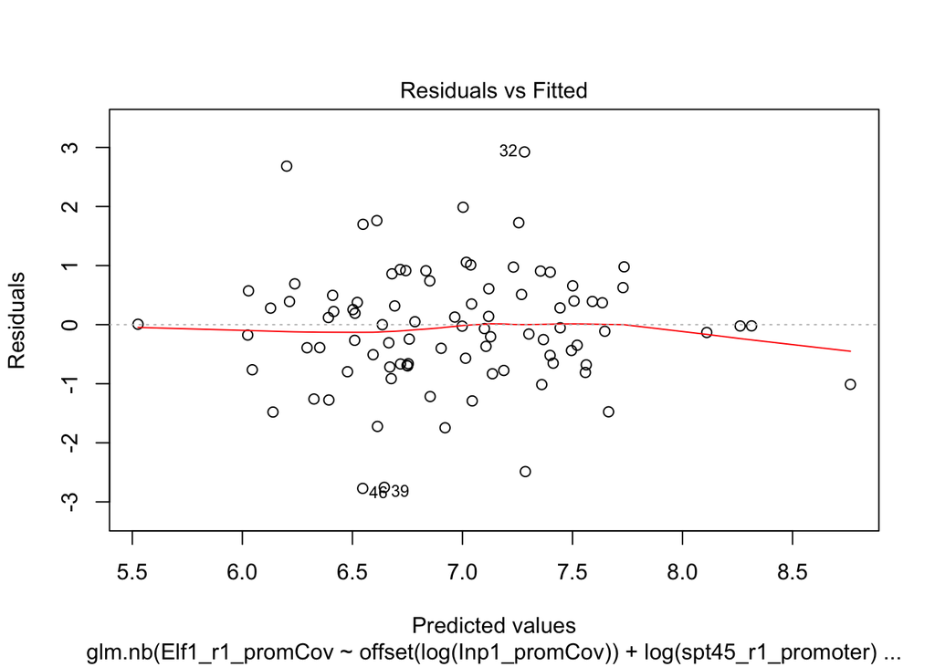

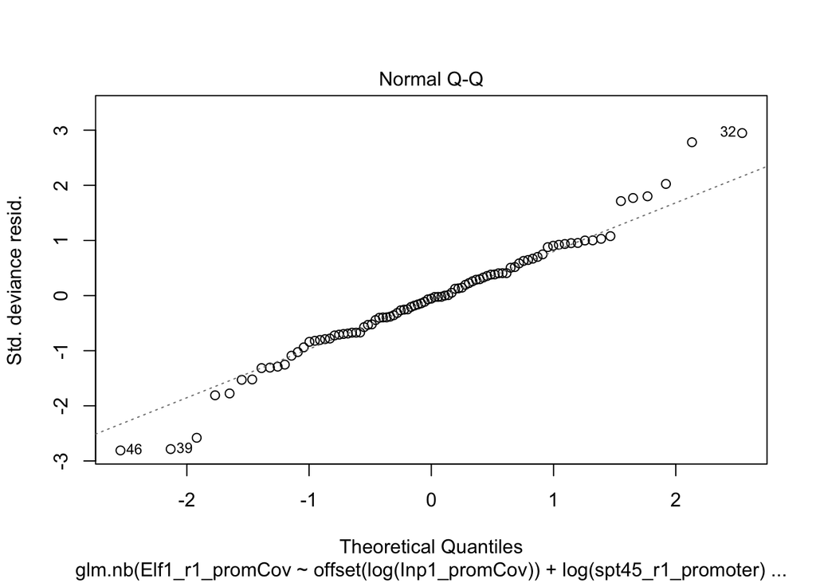

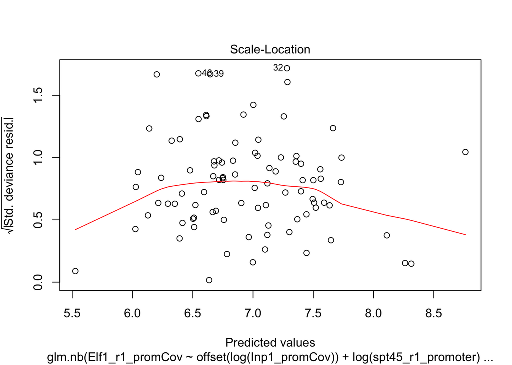

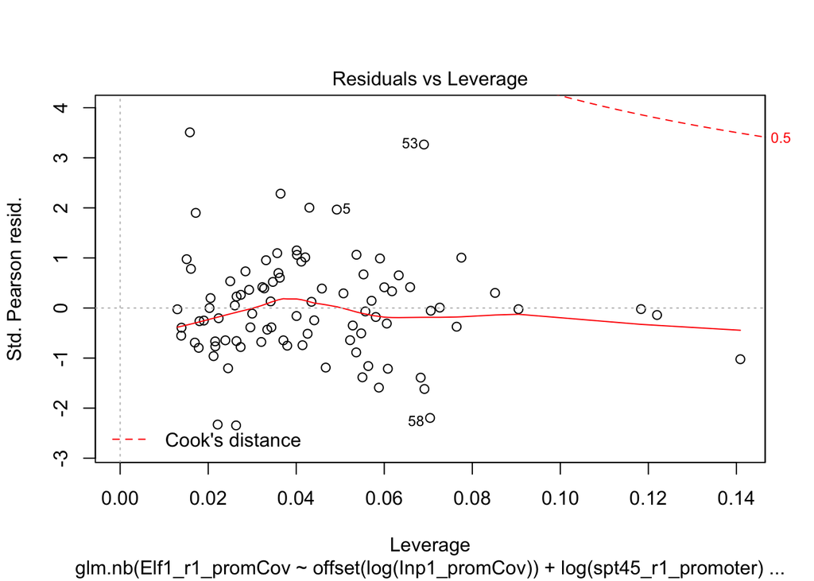

```r
#minimal model after feature selection
model.nb <- suppressWarnings(glm.nb(Elf1_r1_promCov ~ offset(log(Inp1_promCov)) + log(spt45_r1_promoter) + deltaG + log(TFB1_foldR1), data=data.mod))


#plotting
devAskNewPage(ask = FALSE) #turn of requirement to hit "Return" before plotting
plot(model.nb)
```

```r
#LR testing
model.dropSpt45 <- suppressWarnings(glm.nb(Elf1_r1_promCov ~ offset(log(Inp1_promCov)) +  deltaG + log(TFB1_foldR1), data=data.mod))
model.dropDeltaG <- suppressWarnings(glm.nb(Elf1_r1_promCov ~ offset(log(Inp1_promCov)) + log(spt45_r1_promoter) + log(TFB1_foldR1), data=data.mod))
model.dropTFB <- suppressWarnings(glm.nb(Elf1_r1_promCov ~ offset(log(Inp1_promCov)) + log(spt45_r1_promoter) + deltaG, data=data.mod))

anova(model.nb, model.dropSpt45)
```

```
## Likelihood ratio tests of Negative Binomial Models
##
## Response: Elf1_r1_promCov
##                                                                            Model
## 1                          offset(log(Inp1_promCov)) + deltaG + log(TFB1_foldR1)
## 2 offset(log(Inp1_promCov)) + log(spt45_r1_promoter) + deltaG + log(TFB1_foldR1)
##       theta Resid. df    2 x log-lik.   Test    df LR stat. Pr(Chi)
## 1  7.883292        88       -1337.588
## 2 28.517151        87       -1220.094 1 vs 2     1 117.4939       0
```

```r
anova(model.nb, model.dropDeltaG)
```

```
## Likelihood ratio tests of Negative Binomial Models
##
## Response: Elf1_r1_promCov
##                                                                            Model
## 1          offset(log(Inp1_promCov)) + log(spt45_r1_promoter) + log(TFB1_foldR1)
## 2 offset(log(Inp1_promCov)) + log(spt45_r1_promoter) + deltaG + log(TFB1_foldR1)
##      theta Resid. df    2 x log-lik.   Test    df LR stat.      Pr(Chi)
## 1 23.17345        88       -1238.682
## 2 28.51715        87       -1220.094 1 vs 2     1 18.58762 1.622712e-05
```

```r
anova(model.nb, model.dropTFB)
```

```
## Likelihood ratio tests of Negative Binomial Models
##
## Response: Elf1_r1_promCov
##                                                                            Model
## 1                    offset(log(Inp1_promCov)) + log(spt45_r1_promoter) + deltaG
## 2 offset(log(Inp1_promCov)) + log(spt45_r1_promoter) + deltaG + log(TFB1_foldR1)
##      theta Resid. df    2 x log-lik.   Test    df LR stat.     Pr(Chi)
## 1 23.84217        88       -1236.018
## 2 28.51715        87       -1220.094 1 vs 2     1 15.92425 6.59286e-05
```

```r
pR2(model.nb)
```

```
##          llh      llhNull           G2     McFadden         r2ML
## -610.0469672 -717.2495011  214.4050678    0.1494634    0.9052108
##         r2CU
##    0.9052109
```

```r
#Bootstrap
confint(Boot(model.nb,  f=coef, R=1000, method = "case"))
```

```
## Bootstrap bca confidence intervals
##
##                             2.5 %      97.5 %
## (Intercept)            -0.5647629 -0.32111446
## log(spt45_r1_promoter)  0.9208667  1.28647240
## deltaG                 -0.1352176 -0.04967028
## log(TFB1_foldR1)       -0.4863833 -0.12768163
```

Repeat for replicate 2

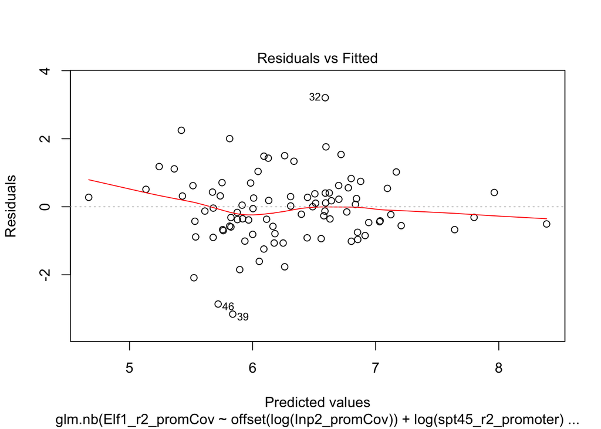

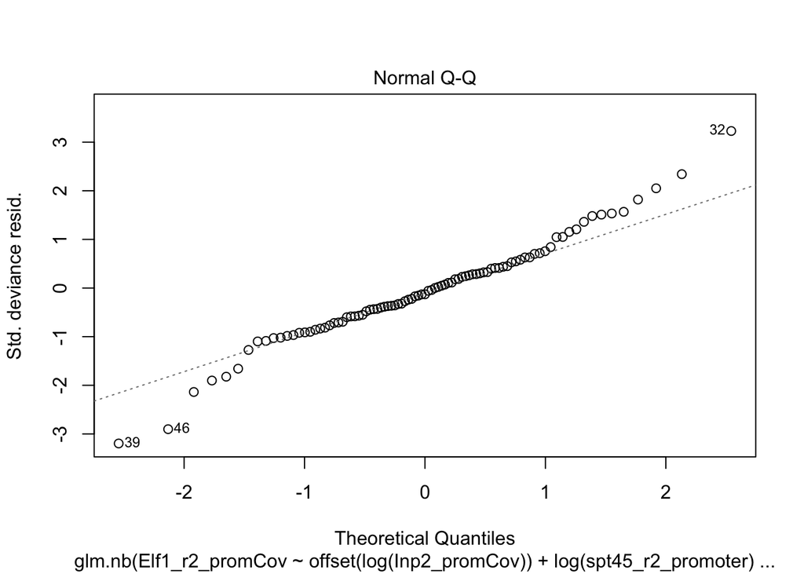

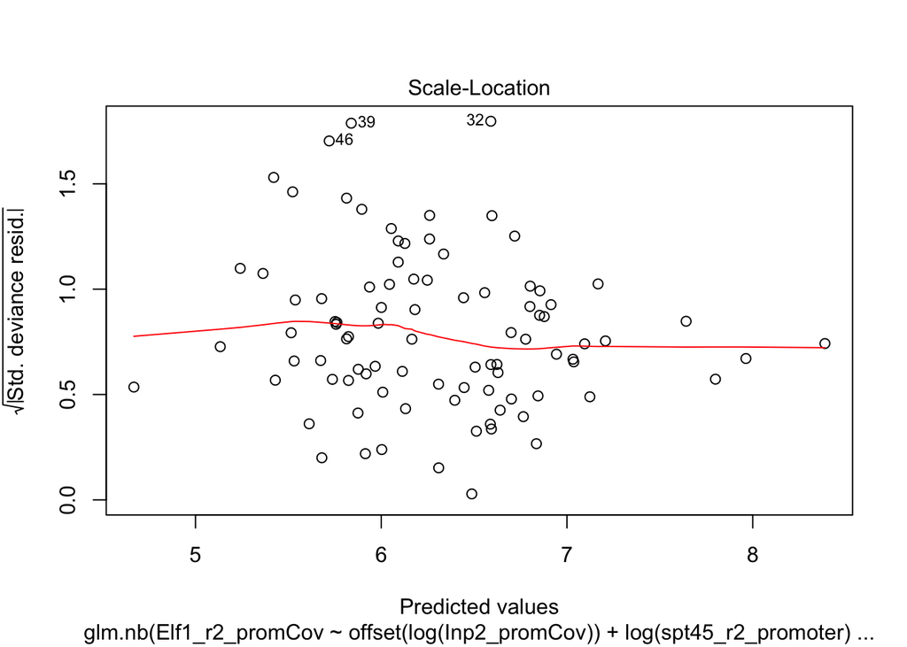

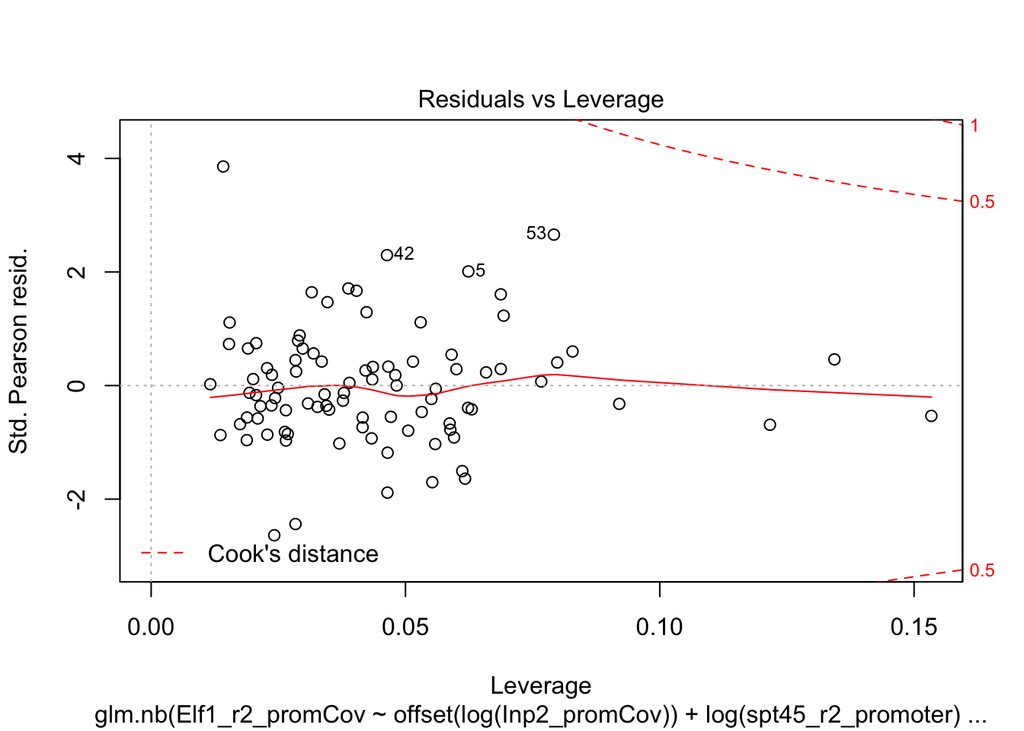

```r
#minimal model after feature selection
model.nb <- suppressWarnings(glm.nb(Elf1_r2_promCov ~ offset(log(Inp2_promCov)) + log(spt45_r2_promoter) + deltaG + log(TFB1_foldR2), data=data.mod))


#plotting
devAskNewPage(ask = FALSE) #turn of requirement to hit "Return" before plotting
plot(model.nb)
```

```r
#LR testing
model.dropSpt45 <- suppressWarnings(glm.nb(Elf1_r2_promCov ~ offset(log(Inp2_promCov)) +  deltaG + log(TFB1_foldR2), data=data.mod))
model.dropDeltaG <- suppressWarnings(glm.nb(Elf1_r2_promCov ~ offset(log(Inp2_promCov)) + log(spt45_r2_promoter) + log(TFB1_foldR2), data=data.mod))
model.dropTFB <- suppressWarnings(glm.nb(Elf1_r2_promCov ~ offset(log(Inp2_promCov)) + log(spt45_r2_promoter) + deltaG, data=data.mod))
model.dropCPSF1 <- suppressWarnings(glm.nb(Elf1_r2_promCov ~ offset(log(Inp2_promCov)) + log(spt45_r2_promoter) + deltaG + log(TFB1_foldR2), data=data.mod))

anova(model.nb, model.dropSpt45)
```

```
## Likelihood ratio tests of Negative Binomial Models
##
## Response: Elf1_r2_promCov
##                                                                            Model
## 1                          offset(log(Inp2_promCov)) + deltaG + log(TFB1_foldR2)
## 2 offset(log(Inp2_promCov)) + log(spt45_r2_promoter) + deltaG + log(TFB1_foldR2)
##       theta Resid. df    2 x log-lik.   Test    df LR stat. Pr(Chi)
## 1  5.805244        88       -1246.926
## 2 32.748957        87       -1091.642 1 vs 2     1 155.2845       0
```

```r
anova(model.nb, model.dropDeltaG)
```

```
## Likelihood ratio tests of Negative Binomial Models
##
## Response: Elf1_r2_promCov
##                                                                            Model
## 1          offset(log(Inp2_promCov)) + log(spt45_r2_promoter) + log(TFB1_foldR2)
## 2 offset(log(Inp2_promCov)) + log(spt45_r2_promoter) + deltaG + log(TFB1_foldR2)
##      theta Resid. df    2 x log-lik.   Test    df LR stat.      Pr(Chi)
## 1 24.80742        88       -1115.448
## 2 32.74896        87       -1091.642 1 vs 2     1 23.80605 1.065469e-06
```

```r
anova(model.nb, model.dropTFB)
```

```
## Likelihood ratio tests of Negative Binomial Models
##
## Response: Elf1_r2_promCov
##                                                                            Model
## 1                    offset(log(Inp2_promCov)) + log(spt45_r2_promoter) + deltaG
## 2 offset(log(Inp2_promCov)) + log(spt45_r2_promoter) + deltaG + log(TFB1_foldR2)
##      theta Resid. df    2 x log-lik.   Test    df LR stat.      Pr(Chi)
## 1 24.77416        88       -1114.944
## 2 32.74896        87       -1091.642 1 vs 2     1 23.30278 1.384001e-06
```

```r
pR2(model.nb)
```

```
##          llh      llhNull           G2     McFadden         r2ML
## -545.8207826 -670.1930706  248.7445761    0.1855768    0.9350058
##         r2CU
##    0.9350062
```

```r
#Bootstrap
confint(Boot(model.nb,  f=coef, R=1000, method = "case"))
```

```
## Bootstrap bca confidence intervals
##
##                             2.5 %      97.5 %
## (Intercept)            -1.1378659 -0.89892628
## log(spt45_r2_promoter)  1.0982144  1.36929202
## deltaG                 -0.1365049 -0.06233209
## log(TFB1_foldR2)       -0.4623353 -0.17052333
```

Automatic model selection with step() function including binary interaction terms

```r
#function to calculate BIC
bic<-function(model) {-model$twologlik  + (length(model$coefficients)+1) * log(nrow(model$model))}

model.null<- suppressWarnings(glm.nb(Elf1_r1_promCov ~ offset(log(Inp1_promCov)), data=data.mod))
#full model including all binary interaction terms
model.bin <- suppressWarnings(glm.nb(Elf1_r1_promCov ~ offset(log(Inp1_promCov)) + log(spt45_r1_promoter) + deltaG + log(TFB1_foldR1) + log(TFEb_foldR1) + log(cpsf1_r1_promoter) + I(log(spt45_r1_promoter)*deltaG) + I(log(spt45_r1_promoter)*log(TFB1_foldR1)) + I(log(spt45_r1_promoter)*log(TFEb_foldR1)) + I(log(spt45_r1_promoter)*log(cpsf1_r1_promoter)) + I(deltaG*log(TFB1_foldR1)) + I(deltaG*log(TFEb_foldR1)) + I(deltaG*log(cpsf1_r1_promoter)) + I(log(TFB1_foldR1)*log(TFEb_foldR1)) + I(log(TFB1_foldR1)*log(cpsf1_r1_promoter)) + I(log(TFEb_foldR1)*log(cpsf1_r1_promoter)), data=data.Merged2))

model.step<-step(object=model.null, scope=list(upper=model.bin$call, lower=model.null$call), data=data.mod, trace=F, direction = "forward", k = log(nrow(data.mod)))
bic(model.step)
```

```
## [1] 1244.338
```

```r
#trying to add single terms to starting model
model.step.spt45<-step(object=update(model.null,  ~ . + log(spt45_r1_promoter)), scope=list(upper=model.bin$call, lower=~1), data=data.mod, trace=F, direction = "forward", k = log(nrow(data.mod)))
bic(model.step.spt45)
```

```
## [1] 1244.338
```

```r
model.step.deltaG<-step(object=update(model.null,  ~ . + deltaG), scope=list(upper=model.bin$call, lower=~1), data=data.mod, trace=F, direction = "forward", k = log(nrow(data.mod)))
bic(model.step.deltaG)
```

```
## [1] 1242.648
```

```r
model.step.TFB<-step(object=update(model.null,  ~ . + log(TFB1_foldR1)), scope=list(upper=model.bin$call, lower=~1), data=data.mod, trace=F, direction = "forward", k = log(nrow(data.mod)))
bic(model.step.TFB)
```

```
## [1] 1242.648
```

```r
model.step.TFEb<-step(object=update(model.null,  ~ . + log(TFEb_foldR1)), scope=list(upper=model.bin$call, lower=~1), data=data.mod, trace=F, direction = "forward", k = log(nrow(data.mod)))
bic(model.step.TFEb)
```

```
## [1] 1246.612
```

```r
model.step.cpsf1<-step(object=update(model.null,  ~ . + log(cpsf1_r1_promoter)), scope=list(upper=model.bin$call, lower=~1), data=data.mod, trace=F, direction = "forward", k = log(nrow(data.mod)))
bic(model.step.cpsf1)
```

```
## [1] 1248.128
```

```r
# checking models with lowest BIC
model.step.deltaG$call
```

```
## glm.nb(formula = Elf1_r1_promCov ~ deltaG + log(spt45_r1_promoter) +
##     log(TFB1_foldR1) + offset(log(Inp1_promCov)), data = data.mod,
##     init.theta = 28.51715089, link = log)
```

```r
model.step.TFB$call
```

```
## glm.nb(formula = Elf1_r1_promCov ~ log(TFB1_foldR1) + log(spt45_r1_promoter) +
##     deltaG + offset(log(Inp1_promCov)), data = data.mod, init.theta = 28.51715089,
##     link = log)
```

Model with lowest BIC does not contain interaction terms, thus it agrees with the minimal model described above.

Repeat for replicate 2

```r
model.null<- suppressWarnings(glm.nb(Elf1_r2_promCov ~ offset(log(Inp2_promCov)), data=data.mod))
#full model including all binary interaction terms
model.bin <- suppressWarnings(glm.nb(Elf1_r2_promCov ~ offset(log(Inp2_promCov)) + log(spt45_r2_promoter) + deltaG + log(TFB1_foldR2) + log(TFEb_foldR2) + log(cpsf1_r2_promoter) + I(log(spt45_r2_promoter)*deltaG) + I(log(spt45_r2_promoter)*log(TFB1_foldR2)) + I(log(spt45_r2_promoter)*log(TFEb_foldR2)) + I(log(spt45_r2_promoter)*log(cpsf1_r2_promoter)) + I(deltaG*log(TFB1_foldR2)) + I(deltaG*log(TFEb_foldR2)) + I(deltaG*log(cpsf1_r2_promoter)) + I(log(TFB1_foldR2)*log(TFEb_foldR2)) + I(log(TFB1_foldR2)*log(cpsf1_r2_promoter)) + I(log(TFEb_foldR2)*log(cpsf1_r2_promoter)), data=data.mod))

model.step<-step(object=model.null, scope=list(upper=model.bin$call, lower=model.null$call), data=data.mod, trace=F, direction = "forward", k = log(nrow(data.mod)))
bic(model.step)
```

```
## [1] 1116.007
```

```r
#trying to add single terms to starting model
model.step.spt45<-step(object=update(model.null,  ~ . + log(spt45_r2_promoter)), scope=list(upper=model.bin$call, lower=~1), data=data.mod, trace=F, direction = "forward", k = log(nrow(data.mod)))
bic(model.step.spt45)
```

```
## [1] 1116.007
```

```r
model.step.deltaG<-step(object=update(model.null,  ~ . + deltaG), scope=list(upper=model.bin$call, lower=~1), data=data.mod, trace=F, direction = "forward", k = log(nrow(data.mod)))
bic(model.step.deltaG)
```

```
## [1] 1114.196
```

```r
model.step.TFB<-step(object=update(model.null,  ~ . + log(TFB1_foldR2)), scope=list(upper=model.bin$call, lower=~1), data=data.mod, trace=F, direction = "forward", k = log(nrow(data.mod)))
bic(model.step.TFB)
```

```
## [1] 1112.978
```

```r
model.step.TFEb<-step(object=update(model.null,  ~ . + log(TFEb_foldR2)), scope=list(upper=model.bin$call, lower=~1), data=data.mod, trace=F, direction = "forward", k = log(nrow(data.mod)))
bic(model.step.TFEb)
```

```
## [1] 1116.219
```

```r
model.step.cpsf1<-step(object=update(model.null,  ~ . + log(cpsf1_r2_promoter)), scope=list(upper=model.bin$call, lower=~1), data=data.mod, trace=F, direction = "forward", k = log(nrow(data.mod)))
bic(model.step.cpsf1)
```

```
## [1] 1119.695
```

```r
# checking model with lowest BIC
model.step.deltaG$call
```

```
## glm.nb(formula = Elf1_r2_promCov ~ deltaG + log(spt45_r2_promoter) +
##     log(TFB1_foldR2) + offset(log(Inp2_promCov)), data = data.mod,
##     init.theta = 32.74895673, link = log)
```

```r
model.step.TFB$call
```

```
## glm.nb(formula = Elf1_r2_promCov ~ log(TFB1_foldR2) + log(spt45_r2_promoter) +
##     I(deltaG * log(TFEb_foldR2)) + offset(log(Inp2_promCov)),
##     data = data.mod, init.theta = 33.15039267, link = log)
```

While model with lowest BIC for replicate 2 agrees with replicate 1 with the exception of TFEb occupancy as interaction term with deltaG, that leads to slight BIC improvement.

Testing if deltaG*TFEb interaction would improve model for replicate 1

```r
model.nb<-suppressWarnings(glm.nb(Elf1_r1_promCov ~ log(TFB1_foldR1) + log(spt45_r1_promoter) +
deltaG + offset(log(Inp1_promCov)),
data = data.mod))
bic(model.nb)
```

```
## [1] 1242.648
```

```r
model.nb.int<-suppressWarnings(glm.nb(Elf1_r1_promCov ~ log(TFB1_foldR1) + log(spt45_r1_promoter) +
I(deltaG * log(TFEb_foldR1)) + offset(log(Inp1_promCov)),
data = data.mod))
bic(model.nb.int)
```

```
## [1] 1243.024
```

Answer: no improvement!

Therefore the consensus model between the two replicates contains the three terms deltaG, TFB and Spt45 promoter occupancy.